# Descriptive Multivariate Analysis: countries by socio-economic-health

Máster en Data Science y Big Data en Finanzas

AFI, 2022

# Motivation

Can we organize the world’s countries by variables we are interested in?

For instance, the World Bank organizes countries in 4 income groups using just the Gross National Income (GNI) per capita

But what if we are interested in health? And in much more variables?

In this case study, we will analyze countries using socio-economic and health indicators that determine the overall development of the world

```r
library(tidyverse)
library(countrycode)
library(rworldmap)
library(GGally)
```

## The dataset

The dataset is obtained through the notebook “WHO_preprocessing.Rmd”, which creates a file named “WorldData2022.txt”. There you can find explanation for the following World Health Organization (WHO) variables:

- Life expectancy at birth (years)
- Infant mortality rate (probability of dying between birth and age 1 per 1000 live births)
- Population (in thousands) total
- Ambient air pollution (Annual PM2.5 [ug/m3])
- Estimates of rates of homicides per 100 000 population
- Hospital beds (per 10 000 population)
- Total expenditure on health as a percentage of gross domestic product
- Percentage of individuals using the Internet
- Physicians density (per 1000 population)

and also from the following The World Happiness Report (WHR) variables:

- Happiness
- GDP per capita
- Healthy life expectancy
- Social support
- Perceived freedom
- Generosity
- Perception of corruption

```r
WHO = read.table("WorldData2022.txt", sep=",")
```

## Descriptive analysis

```r
dim(WHO)
```

```
## [1] 151  21
```

```r
str(WHO)
```

```
## 'data.frame':    151 obs. of  21 variables:
##  $ COUNTRY                 : chr  "AFG" "ALB" "ARE" "ARG" ...
##  $ Country                 : chr  "Afghanistan" "Albania" "United Arab Emirates" "Argentina" ...
##  $ Continent               : chr  "Asia" "Europe" "Asia" "Americas" ...
##  $ Region                  : chr  "South Asia" "Europe & Central Asia" "Middle East & North Africa" "Latin America & Caribbean" ...
##  $ LifeExpectancy          : num  63.2 78 76.1 76.6 76 ...
##  $ IMR                     : num  46.51 8.61 6.4 8.24 10.51 ...
##  $ Population              : num  35530 2873 9400 44271 2930 ...
##  $ AirPollution            : num  55.1 18.1 42.2 13.2 26 ...
##  $ HomicidesRate           : num  13.29 3.56 0.943 10.447 1.502 ...
##  $ HospitalBeds            : num  3.9 28.9 13.8 49.9 41.6 ...
##  $ HealthExpenditure       : num  8.18 5.88 3.64 4.79 4.48 ...
##  $ Internet                : num  5.45 54.66 85 55.8 39.16 ...
##  $ Physicians              : num  0.295 1.286 1.558 3.907 2.803 ...
##  $ country                 : chr  "Afghanistan" "Albania" "United Arab Emirates" "Argentina" ...
##  $ region                  : chr  "South Asia" "Central and Eastern Europe" "Middle East and North Africa" "Latin America and Caribbean" ...
##  $ happiness               : num  2.57 4.88 6.79 5.97 4.68 ...
##  $ gdp                     : num  7.46 9.42 11.11 9.81 9.1 ...
##  $ social_support          : num  0.47 0.671 0.849 0.901 0.757 ...
##  $ perceived_freedom       : num  0.397 0.782 0.941 0.831 0.712 ...
##  $ generosity              : num  -0.0964 -0.0423 0.1235 -0.1949 -0.1388 ...
##  $ perception_of_corruption: num  0.934 0.896 0.595 0.842 0.774 ...
```

```r
head(WHO)
```

```
##   COUNTRY              Country Continent                     Region
## 1     AFG          Afghanistan      Asia                 South Asia
## 2     ALB              Albania    Europe      Europe & Central Asia
## 3     ARE United Arab Emirates      Asia Middle East & North Africa
## 4     ARG            Argentina  Americas  Latin America & Caribbean
## 5     ARM              Armenia      Asia      Europe & Central Asia
## 6     AUS            Australia   Oceania        East Asia & Pacific
##   LifeExpectancy      IMR Population AirPollution HomicidesRate HospitalBeds
## 1       63.20990 46.51282  35530.081        55.14      13.29011        3.900
## 2       78.00018  8.61428   2873.457        18.07       3.56019       28.893
## 3       76.07952  6.40489   9400.145        42.24       0.94339       13.800
## 4       76.57514  8.23805  44271.041        13.15      10.44673       49.920
## 5       76.02519 10.50872   2930.450        26.03       1.50173       41.628
## 6       83.04064  3.05182  24598.933         7.14       0.66419       38.400
##   HealthExpenditure Internet Physicians              country
```

[output cut: 20 more lines]

```r
tail(WHO)
```

```
##     COUNTRY                            Country Continent
## 146     VEN Venezuela (Bolivarian Republic of)  Americas
## 147     VNM                           Viet Nam      Asia
## 148     YEM                              Yemen      Asia
## 149     ZAF                       South Africa    Africa
## 150     ZMB                             Zambia    Africa
## 151     ZWE                           Zimbabwe    Africa
##                         Region LifeExpectancy      IMR Population AirPollution
## 146  Latin America & Caribbean       73.94636 21.03844   31977.06        20.26
## 147        East Asia & Pacific       73.74126 15.88451   95540.80        22.01
## 148 Middle East & North Africa       66.63147 43.62303   28250.42        41.46
## 149         Sub-Saharan Africa       65.25417 27.51648   56717.16        22.24
## 150         Sub-Saharan Africa       62.45290 42.41526   17094.13        31.45
## 151         Sub-Saharan Africa       60.68252 38.42378   16529.90        25.18
##     HomicidesRate HospitalBeds HealthExpenditure Internet Physicians
```

[output cut: 20 more lines]

```r
summary(WHO)
```

```
##    COUNTRY            Country           Continent            Region
##  Length:151         Length:151         Length:151         Length:151
##  Class :character   Class :character   Class :character   Class :character
##  Mode  :character   Mode  :character   Mode  :character   Mode  :character
##
##
##
##
##  LifeExpectancy       IMR           Population         AirPollution
##  Min.   :50.75   Min.   : 1.553   Min.   :    341.3   Min.   : 5.73
##  1st Qu.:67.39   1st Qu.: 4.629   1st Qu.:   4803.8   1st Qu.:13.98
##  Median :74.82   Median :12.354   Median :  10981.2   Median :22.24
##  Mean   :73.30   Mean   :20.492   Mean   :  48518.8   Mean   :28.36
##  3rd Qu.:78.88   3rd Qu.:32.696   3rd Qu.:  35634.8   3rd Qu.:37.21
##  Max.   :84.26   Max.   :81.003   Max.   :1386395.0   Max.   :93.83
##  NA's   :2       NA's   :2                            NA's   :2
##  HomicidesRate      HospitalBeds    HealthExpenditure    Internet
##  Min.   : 0.2095   Min.   :  1.00   Min.   : 1.866    Min.   : 1.069
##  1st Qu.: 1.1552   1st Qu.: 10.00   1st Qu.: 4.987    1st Qu.:12.761
##  Median : 3.5008   Median : 21.50   Median : 6.552    Median :41.000
##  Mean   : 8.3036   Mean   : 28.23   Mean   : 6.898    Mean   :40.853
##  3rd Qu.: 9.4280   3rd Qu.: 40.59   3rd Qu.: 8.723    3rd Qu.:64.500
##  Max.   :79.8265   Max.   :129.80   Max.   :17.141    Max.   :96.000
##  NA's   :2         NA's   :3        NA's   :2         NA's   :4
##    Physicians       country             region            happiness
##  Min.   :0.0180   Length:151         Length:151         Min.   :2.567
##  1st Qu.:0.3568   Class :character   Class :character   1st Qu.:4.700
##  Median :1.6895   Mode  :character   Mode  :character   Median :5.510
##  Mean   :1.7958                                         Mean   :5.461
##  3rd Qu.:3.0235                                         3rd Qu.:6.221
##  Max.   :6.2550                                         Max.   :7.809
##  NA's   :3
##       gdp         social_support   perceived_freedom   generosity
##  Min.   : 6.493   Min.   :0.3195   Min.   :0.3966    Min.   :-0.30091
##  1st Qu.: 8.319   1st Qu.:0.7363   1st Qu.:0.7134    1st Qu.:-0.12778
##  Median : 9.456   Median :0.8292   Median :0.7998    Median :-0.03366
##  Mean   : 9.287   Mean   :0.8081   Mean   :0.7829    Mean   :-0.01554
##  3rd Qu.:10.264   3rd Qu.:0.9068   3rd Qu.:0.8790    3rd Qu.: 0.08453
##  Max.   :11.451   Max.   :0.9747   Max.   :0.9750    Max.   : 0.56066
##
##  perception_of_corruption
##  Min.   :0.1098
##  1st Qu.:0.6828
##  Median :0.7831
##  Mean   :0.7319
##  3rd Qu.:0.8486
##  Max.   :0.9356
##
```

Out of the 200 countries in the world, we have almost complete information (20 variables) for 151 countries:

- Diverse variables (socio-economic and health)
- Just a few missing values

One country is duplicated:

```r
WHO$Country[duplicated(WHO$Country)]
```

```
## [1] "Cyprus"
```

```r
WHO = WHO[-33,]
```

The output of the tools depend directly on the selected variables for the input. This selection is subjective and depends on the application’s objective

```r
X = WHO %>% dplyr::select(-Continent,-Region,-Country, -COUNTRY,-region,-country,-Population)
```

Take care: we are going to omit rows with NAs

```r
dim(WHO)[1]
```

```
## [1] 150
```

```r
dim(na.omit(X))[1]
```

```
## [1] 146
```

```r
id.complete = complete.cases(X)
names = WHO$Country[id.complete]
continent = WHO$Continent[id.complete]
population = WHO$Population[id.complete]

X = X[id.complete,]
row.names(X)=names
```

# Basic Data Analysis

Tables

```r
table(WHO$Continent)
```

```
##
##   Africa Americas     Asia   Europe  Oceania
##       44       23       42       39        2
```

Better with a barplot:

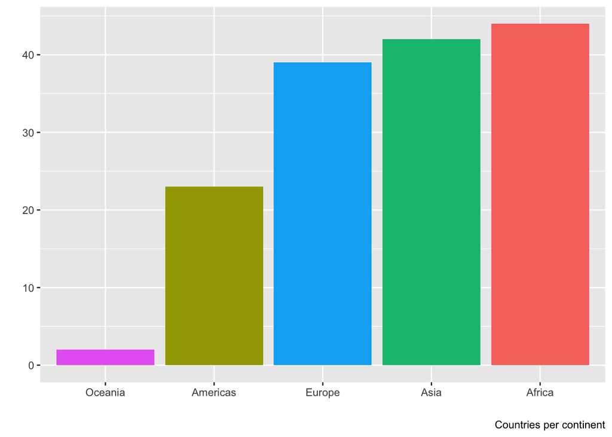

```r
WHO %>% ggplot(aes(x=reorder(Continent, Continent, length))) +geom_bar(aes(fill=Continent)) +
  labs(caption="Countries per continent",
       x = "", y = "")+ theme(legend.position="none")
```

Basic maps:

```r
# select your favourite variable here:
map = WHO %>% dplyr::select(Country, LifeExpectancy)

#Convert the country code into iso3c using the function countrycode()
map$country = countrycode(map$Country, 'country.name', 'iso3c')

#Create data object supporting the map
matched <- joinCountryData2Map(map, joinCode = "ISO3",
                               nameJoinColumn = "country")
```

```
## 150 codes from your data successfully matched countries in the map
## 0 codes from your data failed to match with a country code in the map
## 93 codes from the map weren't represented in your data
```

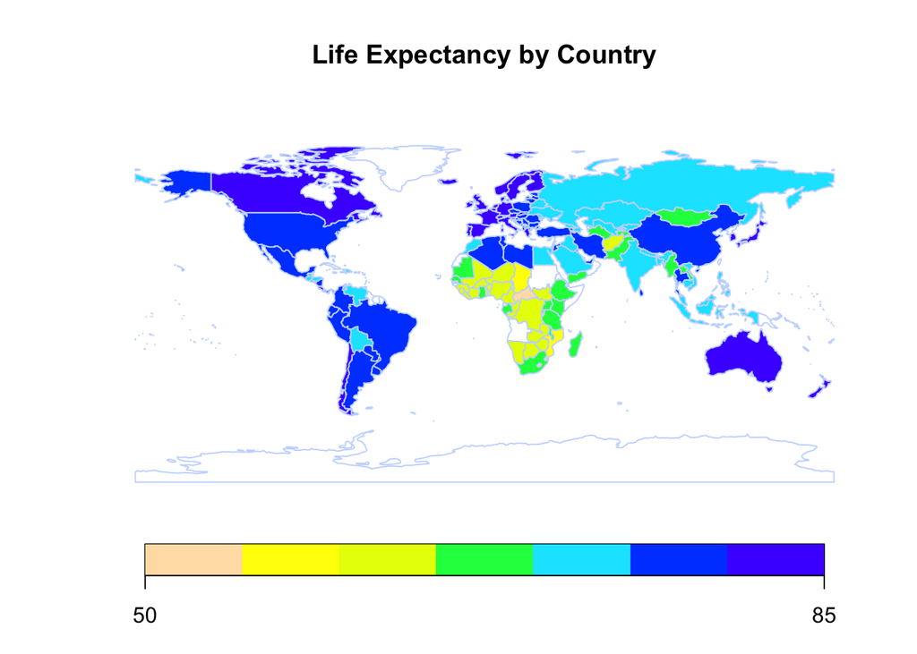

```r
#Draw the map
mapCountryData(matched,nameColumnToPlot="LifeExpectancy",missingCountryCol = "white",
               borderCol = "#C7D9FF",
               catMethod = "pretty", colourPalette = "topo",
               mapTitle = c("Life Expectancy by Country"), lwd=1)
```

Which is the country with the lowest young population?

And the country with the highest senior population? Are they the same?

# Basic descriptive measures

Enter here the vector of means

```r
xbar = colMeans(X)
xbar
```

```
##           LifeExpectancy                      IMR             AirPollution
##              73.28246452              20.45885733              28.46869863
##            HomicidesRate             HospitalBeds        HealthExpenditure
##               8.34916562              28.11529644               6.92630911
##                 Internet               Physicians                happiness
##              40.71479089               1.78723973               5.48399794
##                      gdp           social_support        perceived_freedom
##               9.28326069               0.80903181               0.78698110
##               generosity perception_of_corruption
##              -0.01548447               0.73353233
```

Enter here the covariance matrix

```r
S = cov(X)
S
```

```
##                          LifeExpectancy          IMR AirPollution HomicidesRate
## LifeExpectancy              53.32704116 -131.2093718  -75.4129471   -25.5825058
## IMR                       -131.20937176  393.0027329  221.6274221    57.1110124
## AirPollution               -75.41294713  221.6274221  353.7789411    11.4644528
## HomicidesRate              -25.58250583   57.1110124   11.4644528   193.5184429
## HospitalBeds                86.68137345 -273.4040954 -210.9859491   -87.7906978
## HealthExpenditure            6.97484488  -16.6050574  -22.7143095    -2.6199739
## Internet                   178.67416524 -464.1013095 -324.9704042   -92.1239588
## Physicians                   8.13142200  -22.0941280  -16.6702957    -6.0184899
## happiness                    6.25352550  -14.9826864  -10.5595686    -1.3673560
## gdp                          7.35767968  -19.8132549  -12.5153727    -3.5325762
## social_support               0.63430072   -1.7744678   -1.3426894    -0.1481540
## perceived_freedom            0.33911075   -0.9062953   -0.6938214    -0.0881874
## generosity                  -0.07157148    0.4698491    0.1107651    -0.2881449
## perception_of_corruption    -0.41663040    0.8211189    0.7732111     0.5694786
##                          HospitalBeds HealthExpenditure     Internet
## LifeExpectancy             86.6813735       6.974844878  178.6741652
## IMR                      -273.4040954     -16.605057394 -464.1013095
## AirPollution             -210.9859491     -22.714309460 -324.9704042
## HomicidesRate             -87.7906978      -2.619973896  -92.1239588
## HospitalBeds              575.2175665      16.488444777  388.6469978
## HealthExpenditure          16.4884448       6.539612640   34.4601256
## Internet                  388.6469978      34.460125585  879.2057183
## Physicians                 24.1050944       1.624480067   34.4914472
## happiness                   9.8873189       1.099368643   26.1375871
## gdp                        15.5996336       0.909305304   31.1459450
## social_support              1.4878169       0.101703030    2.5388005
## perceived_freedom           0.1445173       0.044080256    1.3463144
## generosity                 -0.8707015      -0.002167821   -0.3641067
## perception_of_corruption   -0.2205082      -0.132337929   -2.1053029
##                            Physicians    happiness          gdp social_support
## LifeExpectancy             8.13142200   6.25352550   7.35767968    0.634300717
## IMR                      -22.09412801 -14.98268637 -19.81325488   -1.774467776
## AirPollution             -16.67029569 -10.55956860 -12.51537273   -1.342689422
## HomicidesRate             -6.01848995  -1.36735602  -3.53257621   -0.148153953
## HospitalBeds              24.10509442   9.88731889  15.59963359    1.487816904
## HealthExpenditure          1.62448007   1.09936864   0.90930530    0.101703030
## Internet                  34.49144717  26.13758713  31.14594498    2.538800458
## Physicians                 2.24072948   1.10135390   1.35721914    0.122981905
## happiness                  1.10135390   1.23050447   1.03580620    0.103073392
```

[output cut: 20 more lines]

```
##                          perception_of_corruption
## LifeExpectancy                       -0.416630404
## IMR                                   0.821118887
## AirPollution                          0.773211051
## HomicidesRate                         0.569478624
## HospitalBeds                         -0.220508179
## HealthExpenditure                    -0.132337929
## Internet                             -2.105302867
## Physicians                           -0.073621133
## happiness                            -0.085310387
## gdp                                  -0.068565435
## social_support                       -0.004594697
## perceived_freedom                    -0.008987774
## generosity                           -0.007590888
## perception_of_corruption              0.031086370
```

Enter here the correlation matrix

```r
R = cor(X)
R
```

```
##                          LifeExpectancy        IMR AirPollution HomicidesRate
## LifeExpectancy               1.00000000 -0.9063445  -0.54904277   -0.25183040
## IMR                         -0.90634455  1.0000000   0.59437389    0.20709084
## AirPollution                -0.54904277  0.5943739   1.00000000    0.04381534
## HomicidesRate               -0.25183040  0.2070908   0.04381534    1.00000000
## HospitalBeds                 0.49492110 -0.5750309  -0.46770442   -0.26313054
## HealthExpenditure            0.37349500 -0.3275417  -0.47223431   -0.07364780
## Internet                     0.82516874 -0.7895320  -0.58268330   -0.22333982
## Physicians                   0.74387171 -0.7445337  -0.59208301   -0.28902249
## happiness                    0.77198628 -0.6813187  -0.50610262   -0.08860920
## gdp                          0.83964201 -0.8328851  -0.55450418   -0.21162033
## social_support               0.71074059 -0.7324197  -0.58411618   -0.08714485
## perceived_freedom            0.40009008 -0.3938782  -0.31781303   -0.05461794
## generosity                  -0.06392796  0.1545913   0.03841153   -0.13510587
## perception_of_corruption    -0.32358785  0.2349218   0.23315625    0.23218344
##                          HospitalBeds HealthExpenditure    Internet Physicians
## LifeExpectancy             0.49492110       0.373495004  0.82516874  0.7438717
## IMR                       -0.57503087      -0.327541689 -0.78953204 -0.7445337
## AirPollution              -0.46770442      -0.472234310 -0.58268330 -0.5920830
## HomicidesRate             -0.26313054      -0.073647799 -0.22333982 -0.2890225
## HospitalBeds               1.00000000       0.268836116  0.54650482  0.6714258
## HealthExpenditure          0.26883612       1.000000000  0.45445992  0.4243690
## Internet                   0.54650482       0.454459924  1.00000000  0.7770902
## Physicians                 0.67142584       0.424369009  0.77709023  1.0000000
## happiness                  0.37163865       0.387548210  0.79465504  0.6632703
## gdp                        0.54203253       0.296319846  0.87535313  0.7555832
## social_support             0.50760171       0.325422470  0.70060458  0.6722583
## perceived_freedom          0.05191509       0.148510811  0.39119314  0.2312555
## generosity                -0.23679787      -0.005529323 -0.08009547 -0.1823598
## perception_of_corruption  -0.05214632      -0.293510279 -0.40270250 -0.2789477
##                           happiness        gdp social_support perceived_freedom
## LifeExpectancy            0.7719863  0.8396420     0.71074059        0.40009008
## IMR                      -0.6813187 -0.8328851    -0.73241965       -0.39387817
## AirPollution             -0.5061026 -0.5545042    -0.58411618       -0.31781303
## HomicidesRate            -0.0886092 -0.2116203    -0.08714485       -0.05461794
## HospitalBeds              0.3716386  0.5420325     0.50760171        0.05191509
## HealthExpenditure         0.3875482  0.2963198     0.32542247        0.14851081
## Internet                  0.7946550  0.8753531     0.70060458        0.39119314
## Physicians                0.6632703  0.7555832     0.67225828        0.23125553
## happiness                 1.0000000  0.7781511     0.76031687        0.57317595
## gdp                       0.7781511  1.0000000     0.78348775        0.41362227
## social_support            0.7603169  0.7834877     1.00000000        0.46917891
## perceived_freedom         0.5731760  0.4136223     0.46917891        1.00000000
## generosity                0.0649142 -0.1307631    -0.05486732        0.25406207
## perception_of_corruption -0.4361896 -0.3240763    -0.21323648       -0.43919471
##                            generosity perception_of_corruption
## LifeExpectancy           -0.063927957              -0.32358785
## IMR                       0.154591340               0.23492176
## AirPollution              0.038411532               0.23315625
## HomicidesRate            -0.135105872               0.23218344
## HospitalBeds             -0.236797868              -0.05214632
## HealthExpenditure        -0.005529323              -0.29351028
## Internet                 -0.080095471              -0.40270250
## Physicians               -0.182359775              -0.27894769
## happiness                 0.064914197              -0.43618960
## gdp                      -0.130763117              -0.32407629
## social_support           -0.054867322              -0.21323648
## perceived_freedom         0.254062070              -0.43919471
## generosity                1.000000000              -0.28082263
## perception_of_corruption -0.280822633               1.00000000
```

heterogeneous data units:

```r
det(S)
```

```
## [1] 29892.85
```

```r
sum(diag(S))
```

```
## [1] 2459.584
```

highly correlated data:

```r
det(R)
```

```
## [1] 1.079232e-05
```

```r
sum(diag(R))
```

```
## [1] 14
```

## Relations in dimension 1

Univariate analysis for all p=14 variables

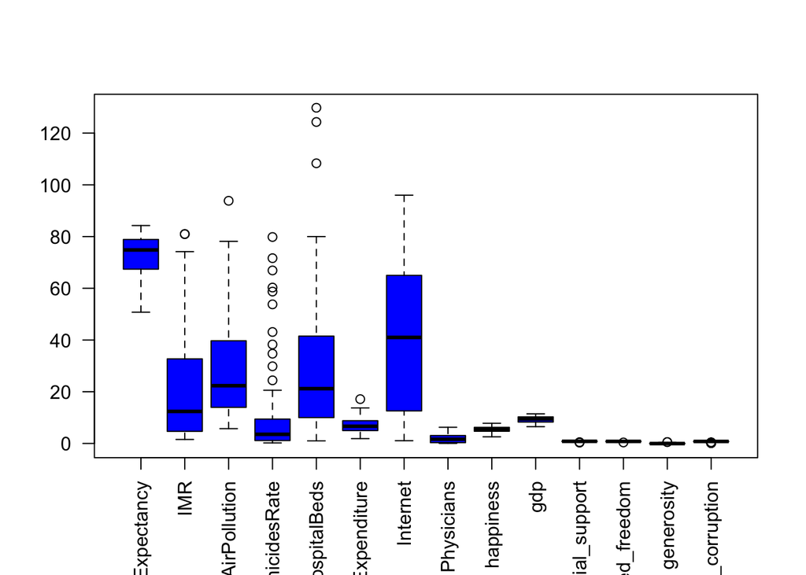

```r
boxplot(X, col="blue", las=2)
```

Scale or not to scale?

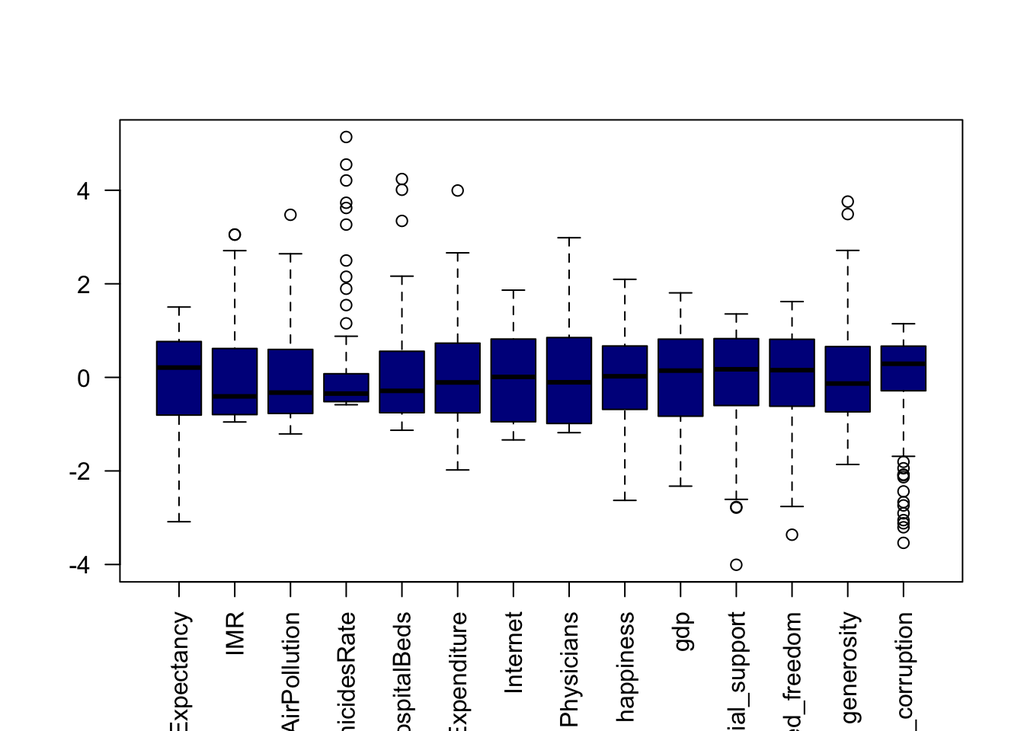

```r
boxplot(scale(X), las=2, col="darkblue")
```

## Relations in dimension 2

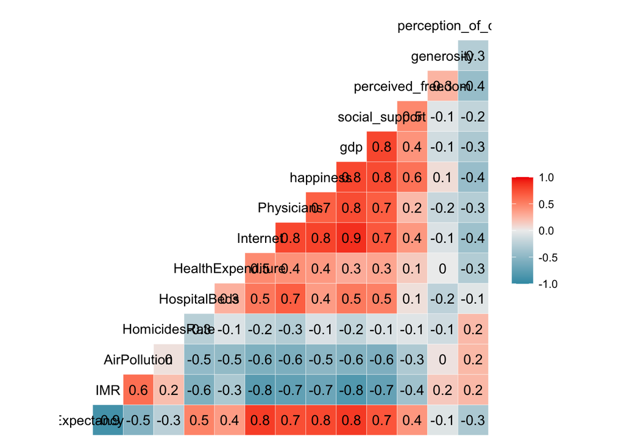

```r
ggcorr(X, label = T)
```

Insights?

For instance, happiness is highly correlated with GDP, social support, and population using internet. And negatively correlated with infant mortality rate

## Relations in dimension 3

In general, no way to obtain information…

But sometimes we can…

For instance, this is 4D using a scatterplot (2D)

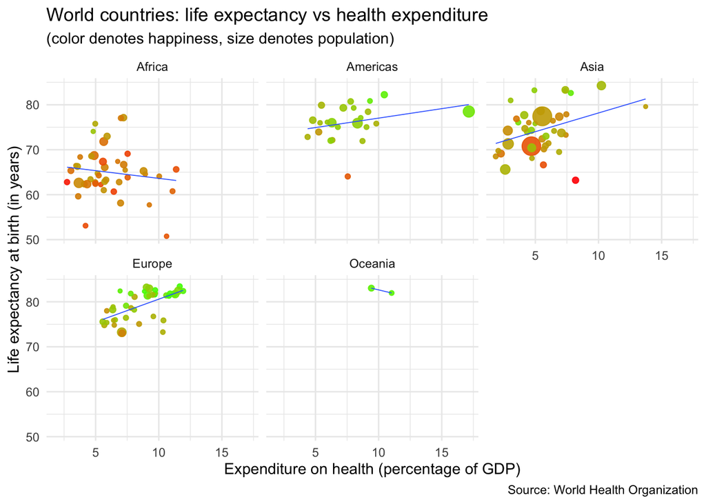

```r
ggplot(WHO, aes(x=HealthExpenditure, y=LifeExpectancy, group=Continent, size=Population, color=happiness)) +
  geom_point(alpha=0.9) + geom_smooth(method=lm,se=F, size=0.3) +
  facet_wrap(~ Continent) +
  scale_color_gradient(low="red", high="green") +
  theme_minimal()+ theme(legend.position="none") +
  labs(title = "World countries: life expectancy vs health expenditure", subtitle="(color denotes happiness, size denotes population)",caption="Source: World Health Organization",
       x = "Expenditure on health (percentage of GDP)", y = "Life expectancy at birth (in years)")
```

Is wealth a determinant of happiness?

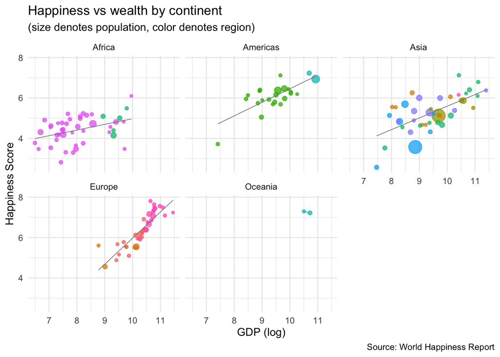

```r
WHO %>% ggplot(aes(x=gdp, y=happiness, group=Continent, size=Population, color=region)) +
  geom_point(alpha=0.75) + geom_smooth(method=lm,se=F, size=0.3) +
  facet_wrap(~ Continent) +
  theme_minimal()+ theme(legend.position="none") +
  labs(title = "Happiness vs wealth by continent", subtitle="(size denotes population, color denotes region)",caption="Source: World Happiness Report",
       x = "GDP (log)", y = "Happiness Score")
```

# Multivariate standardization

This is very useful to compute distances considering correlations: Mahalanobis distance

```r
S_x <- cov(X)
iS <- solve(S_x)
e <- eigen(iS)
V <- e$vectors
B <- V %*% diag(sqrt(e$values)) %*% t(V)
Xtil <- scale(X,scale = FALSE)
X.S <- Xtil %*% B
```

Mahalanobis distances between each country and the world’s center:

```r
muhat = colMeans(X)
dM2 <- mahalanobis(X,muhat,S)  # Mahalanobis distances (square)
dM2
```

```
##                                          Afghanistan
##                                            19.400569
##                                              Albania
##                                            11.521194
##                                 United Arab Emirates
##                                            17.026565
##                                            Argentina
##                                             8.071688
##                                              Armenia
##                                             6.240038
##                                            Australia
##                                             5.592839
##                                              Austria
##                                            11.781076
##                                           Azerbaijan
##                                             9.259817
##                                              Burundi
##                                            16.664965
##                                              Belgium
##                                             4.627750
##                                                Benin
##                                            20.736121
##                                         Burkina Faso
##                                             6.690415
##                                           Bangladesh
##                                            13.559940
##                                             Bulgaria
##                                             9.823673
##                                              Bahrain
##                                            24.989271
##                               Bosnia and Herzegovina
##                                            12.811181
##                                              Belarus
##                                            21.829904
##                     Bolivia (Plurinational State of)
##                                             6.623666
##                                               Brazil
##                                            16.280420
##                                             Botswana
##                                            23.657139
```

[output cut: 237 more lines]

```
##                                            27.394493
##                                           Uzbekistan
##                                            14.124229
##                   Venezuela (Bolivarian Republic of)
##                                            13.693110
##                                             Viet Nam
##                                             8.279457
##                                                Yemen
##                                            18.562627
##                                         South Africa
##                                            21.448636
##                                               Zambia
##                                             6.589666
##                                             Zimbabwe
##                                            12.582197
```

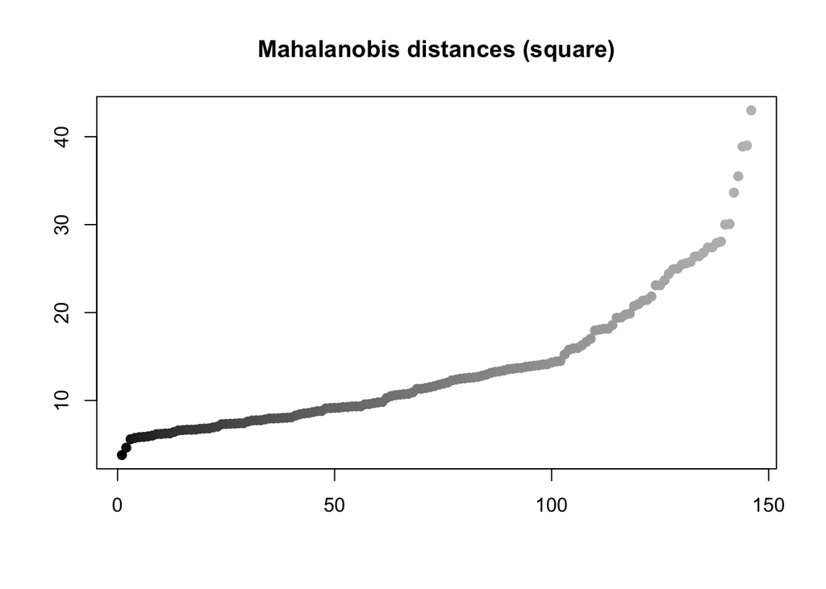

```r
plot(sort(dM2,index.return=TRUE)$x,pch=19,col=grey.colors(n=length(dM2),start=0,end=.75),xlab="",ylab="",main="Mahalanobis distances (square)")
```

```r
sort(dM2)
```

```
##                                              Croatia
##                                             3.790412
##                                              Belgium
##                                             4.627750
##                                            Australia
##                                             5.592839
##                                                Ghana
##                                             5.736290
##                                             Slovenia
##                                             5.822049
##                                                 Togo
##                                             5.855735
##                                            Mauritius
##                                             5.916104
##                                              Senegal
##                                             6.000432
##                                                Spain
##                                             6.167339
##                                             Slovakia
##                                             6.188814
##                                              Armenia
##                                             6.240038
##                                           Kazakhstan
##                                             6.255211
##                                              Estonia
##                                             6.414676
##                                               Zambia
##                                             6.589666
##                     Bolivia (Plurinational State of)
##                                             6.623666
##                                               Serbia
##                                             6.669776
##                                               France
##                                             6.670513
##                                         Burkina Faso
##                                             6.690415
##                                              Ecuador
##                                             6.771338
##                                              Hungary
##                                             6.800899
```

[output cut: 237 more lines]

```
##                                            28.066950
##                                  Trinidad and Tobago
##                                            30.003806
##                                              Lesotho
##                                            30.069247
##                                               Rwanda
##                                            33.637604
##                                              Jamaica
##                                            35.497078
##                                    Republic of Korea
##                                            38.877200
##                             Central African Republic
##                                            38.995569
##                                                Japan
##                                            42.995159
```

Closest countries to Spain:

```r
dM2 <- mahalanobis(X,t(X["Spain",]),S)
head(sort(dM2))
```

```
##    Spain    Italy   Israel  Croatia   Cyprus Slovakia
## 0.000000 3.431149 4.530358 5.212673 7.197686 7.798652
```

# Motivation to PCA

What is the happiest country?

What is the country with the highest life expectancy? Is it the same?

What is the country with the lowest IMR?

Can we rank the countries considering all the variables at the same time?

## From dimension X to dimension 2

```r
pca = prcomp(X, scale=T)
summary(pca)
```

```
## Importance of components:
##                           PC1    PC2     PC3     PC4     PC5     PC6     PC7
## Standard deviation     2.6648 1.3048 1.06715 0.98128 0.81730 0.71451 0.68389
## Proportion of Variance 0.5072 0.1216 0.08134 0.06878 0.04771 0.03647 0.03341
## Cumulative Proportion  0.5072 0.6288 0.71019 0.77897 0.82668 0.86315 0.89655
##                            PC8     PC9    PC10    PC11    PC12    PC13    PC14
## Standard deviation     0.63353 0.54926 0.47680 0.45350 0.40010 0.29752 0.25224
## Proportion of Variance 0.02867 0.02155 0.01624 0.01469 0.01143 0.00632 0.00454
## Cumulative Proportion  0.92522 0.94677 0.96301 0.97770 0.98913 0.99546 1.00000
```

With 2 components we explain 63% of variability

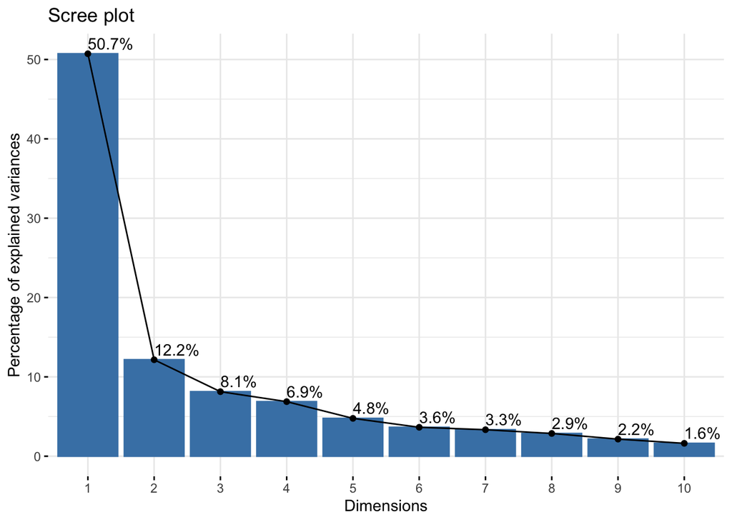

```r
library(factoextra)

fviz_screeplot(pca, addlabels = TRUE)
```

First component?

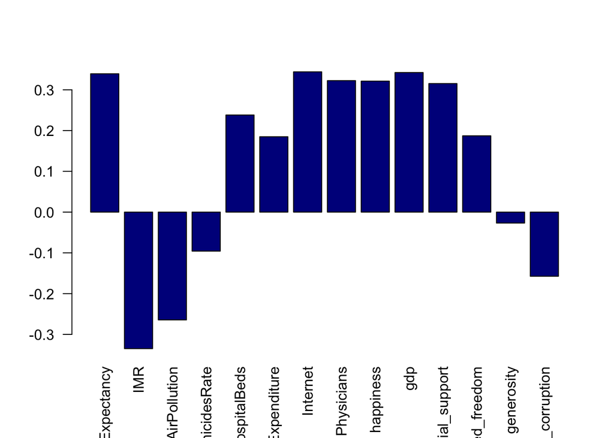

```r
barplot(pca$rotation[,1], las=2, col="darkblue")
```

It is a measure of global development (positive loads on good indicators and negative ones on the bad variables)

The most important indicators are: Internet, gdp, LifeExpectancy, IMR, happiness, etc.

Note the sum of the squared loadings (eigenvectors) is equal to 1

```r
sum(pca$rotation[,1]^2)
```

```
## [1] 1
```

That means squared loadings are easier to interpret than the loadings

I.e. they are like percentages (numbers between 0 and 1), but we loose the sign

Let’s plot squared loadings instead.

They are called contribution of variables to components

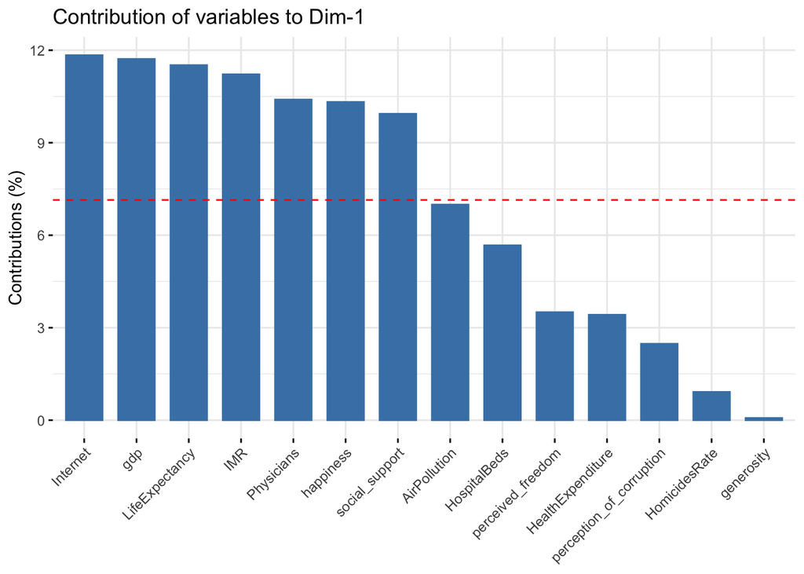

```r
fviz_contrib(pca, choice = "var", axes = 1)
```

The red dashed line on the graph above indicates the expected average contribution

If the contribution of the variables were uniform, the expected value would be 1/length(variables) = 1/14 = 7%

## Rank the countries by the first component (scores)

```r
names[order(pca$x[,1])][1:10]
```

```
##  [1] "Central African Republic"         "Afghanistan"
##  [3] "Chad"                             "Sierra Leone"
##  [5] "Niger"                            "Democratic Republic of the Congo"
##  [7] "Burundi"                          "Guinea"
##  [9] "Togo"                             "Benin"
```

```r
names[order(pca$x[,1], decreasing=T)][1:10]
```

```
##  [1] "Norway"      "Switzerland" "Austria"     "Sweden"      "Denmark"
##  [6] "Finland"     "Germany"     "Netherlands" "New Zealand" "Iceland"
```

Second component?

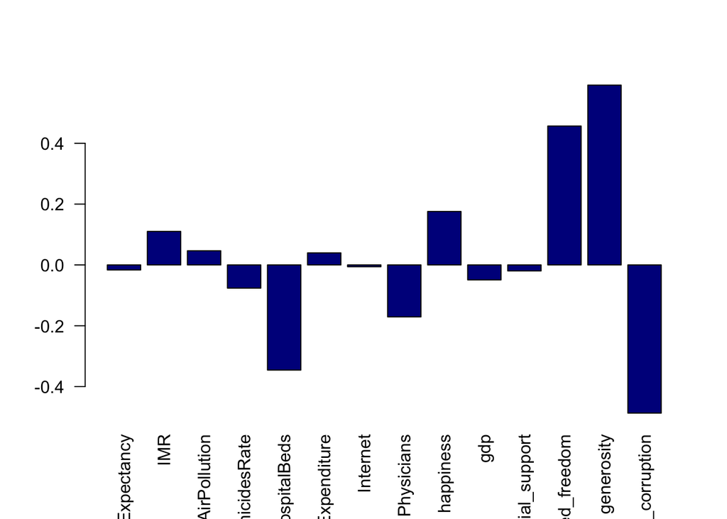

```r
barplot(pca$rotation[,2], las=2, col="darkblue")
```

Contribution of variables to second component

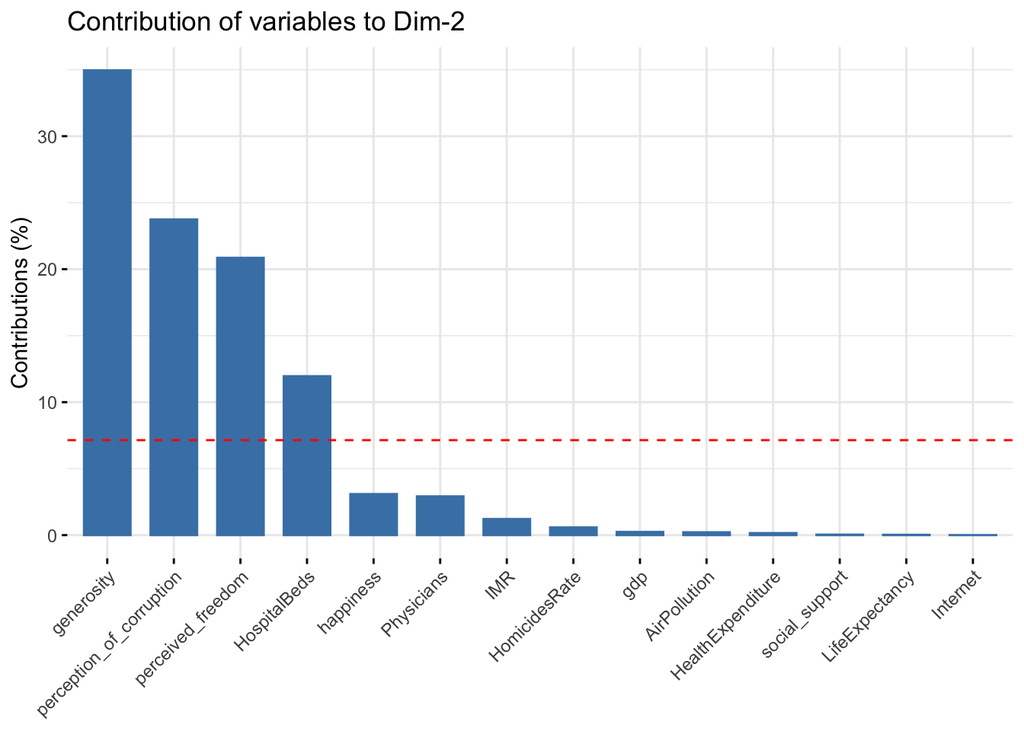

```r
fviz_contrib(pca, choice = "var", axes = 2)
```

# Plot the first two scores

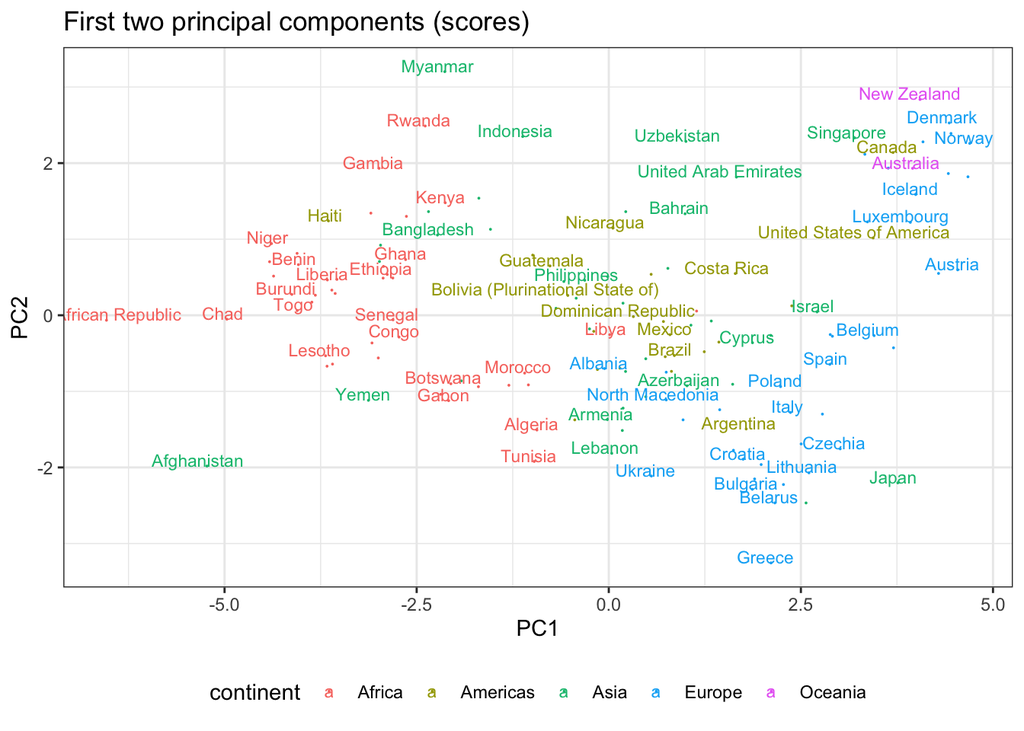

```r
data.frame(z1=pca$x[,1],z2=pca$x[,2]) %>%
  ggplot(aes(z1,z2,label=names,color=continent)) + geom_point(size=0) +
  labs(title="First two principal components (scores)", x="PC1", y="PC2") + #guides(color=guide_legend(title="HDI"))+
  theme_bw() +theme(legend.position="bottom") + geom_text(size=3, hjust=0.6, vjust=0, check_overlap = TRUE)
```

```r
# The two first PCs seem independent
```

Conclusions?

Map:

```r
# Map our PCA index in a map:
map = data.frame(country=names, value=pca$x[,1])
#Convert the country code into iso3c using the function countrycode()
map$country = countrycode(map$country, 'country.name', 'iso3c')
#Create data object supporting the map
matched <- joinCountryData2Map(map, joinCode = "ISO3",
                               nameJoinColumn = "country")
```

```
## 146 codes from your data successfully matched countries in the map
## 0 codes from your data failed to match with a country code in the map
## 97 codes from the map weren't represented in your data
```

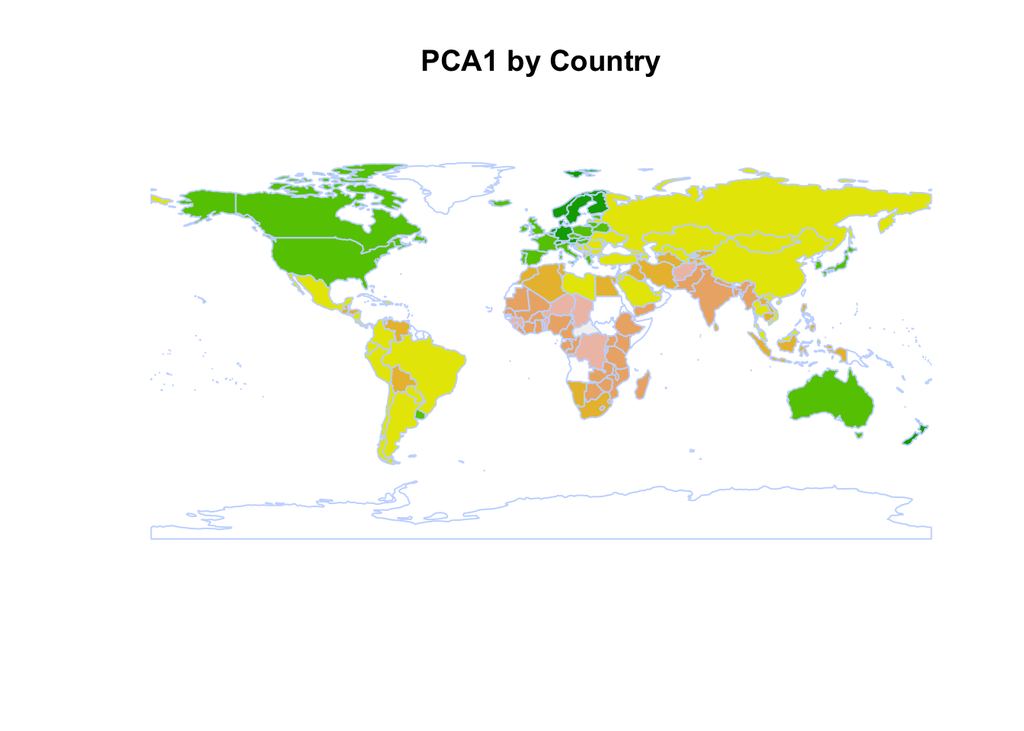

```r
#Draw the map
mapCountryData(matched,nameColumnToPlot="value",missingCountryCol = "white",
               addLegend = FALSE, borderCol = "#C7D9FF",
               catMethod = "pretty", colourPalette = "terrain",
               mapTitle = c("PCA1 by Country"), lwd=1)
```

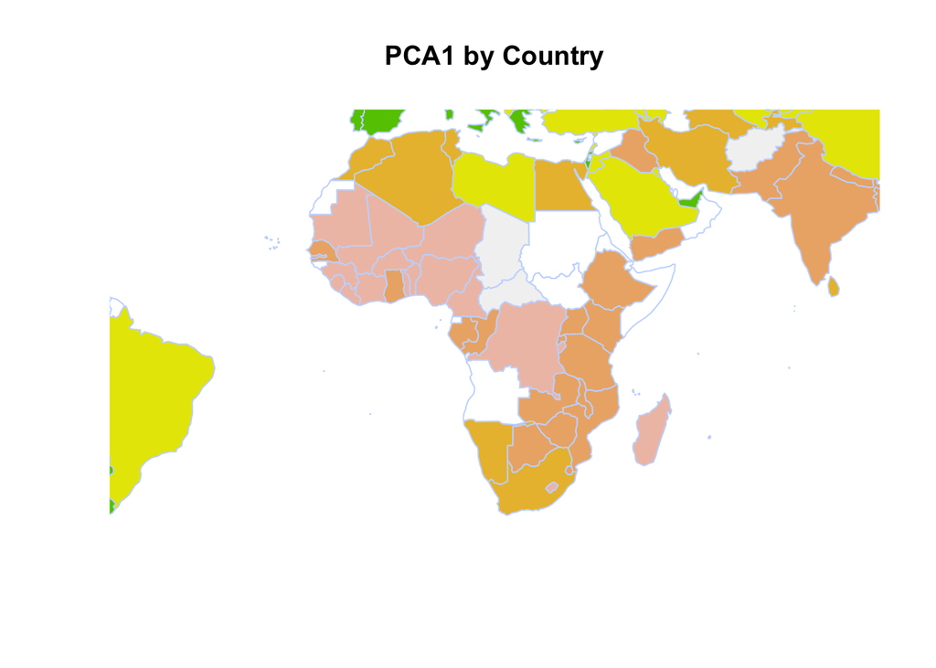

```r
# zoom in Africa
mapCountryData(matched, nameColumnToPlot="value", ,missingCountryCol = "white",
               addLegend = FALSE, borderCol = "#C7D9FF",
               mapRegion = "Africa", mapTitle = c("PCA1 by Country"), lwd=1,
               catMethod = "quantile", colourPalette = "terrain")
```